# Cancer Epidemiology

*by Dr Jason Wong*

*Date: 16-11-2022*

[The RMarkdown notebook to run your own code can be downloaded here](https://github.com/StatBiomed/BMDS-book/raw/main/notebooks/module5-epidemi/M5-epidemiology.Rmd)

## 1. Scenario

You are a grants officer working for the Hong Kong Health Bureau. The HK government has recently announced new special funding in cancer research to be administered by the Bureau. You are tasked with coming up with a proposal for distribution of funding to specific cancer types that are in most need of research.

Discussion points:

- What is important to consider when selecting a cancer type in need of research?
- What type of data is required?

## 2. Hong Kong population

You are aware that generally cancer is disease that affects the elderly more than the young. You decide to first take a closer look at the structure of the population of Hong Kong.

[Historic population of Hong Kong](https://www.censtatd.gov.hk/en/web_table.html?id=1A) can be obtained from the Census and Statistics Department.

An abridged version of the full historic population of Hong Kong is provided here containing the population of Hong Kong from 1965, 1975, 1985, 1995, 2005, 2015 and 2022 categorised by sex and age (0-19, 20-44, 45-64, 65+).

Discussion points:

- What is the trend in Hong Kong’s population over the past ~60 years?
- What is the best way to visualise this data?

### Download population data

```r
HKPop<- read.table("https://github.com/StatBiomed/BMDS-book/raw/main/notebooks/module5-epidemi/HK_population_1965-2022.txt",
    sep = "\t", header = TRUE, stringsAsFactor=FALSE, check.names = FALSE)
HKPop
```

```
##      Sex   Age  1965  1975   1985   1995   2005   2015   2022
## 1   male  0-19 901.9 989.7  909.0  835.6  719.0  613.8  530.6
## 2   male 20-44 607.4 795.6 1210.2 1363.7 1263.7 1146.9 1039.2
## 3   male 45-64 266.5 414.3  525.9  615.7  896.6 1084.9 1046.2
## 4   male   65+  42.2  84.6  170.5  269.3  384.7  520.0  713.6
## 5 female  0-19 865.6 938.8  840.3  780.7  684.1  575.0  502.1
## 6 female 20-44 539.3 685.6 1093.7 1423.6 1530.4 1531.8 1338.7
## 7 female 45-64 286.3 400.7  470.7  535.0  884.7 1224.3 1314.7
## 8 female   65+  88.7 152.3  235.9  332.5  450.0  594.6  806.5
```

### Format data for plotting

Here we convert the original dataframe into simplified format for ggplot2.

```r
male<-data.frame(year = as.numeric(colnames(HKPop[1,3:9])),
                 `0-19`  = as.numeric(HKPop[1,3:9]),
                 `20-44` = as.numeric(HKPop[2,3:9]),
                 `45-64` = as.numeric(HKPop[3,3:9]),
                 `65+` = as.numeric(HKPop[4,3:9]),
                 check.names = FALSE)



female<-data.frame(year = as.numeric(colnames(HKPop[1,3:9])),
                 `0-19`  = as.numeric(HKPop[5,3:9]),
                 `20-44` = as.numeric(HKPop[6,3:9]),
                 `45-64` = as.numeric(HKPop[7,3:9]),
                 `65+` = as.numeric(HKPop[8,3:9]),
                 check.names = FALSE)

if (!require("tidyverse")) install.packages("tidyverse")
male<-as_tibble(male) %>% select(year,`0-19`,`20-44`,`45-64`,`65+`) %>% gather (key="age",value="population ('000s)",-year)
female<-as_tibble(female) %>% select(year,`0-19`,`20-44`,`45-64`,`65+`) %>% gather (key="age",value="population ('000s)",-year)
male
```

```
## # A tibble: 28 × 3
##     year age   `population ('000s)`
##    <dbl> <chr>                <dbl>
##  1  1965 0-19                  902.
##  2  1975 0-19                  990.
##  3  1985 0-19                  909
##  4  1995 0-19                  836.
##  5  2005 0-19                  719
##  6  2015 0-19                  614.
##  7  2022 0-19                  531.
##  8  1965 20-44                 607.
##  9  1975 20-44                 796.
## 10  1985 20-44                1210.
## # … with 18 more rows
```

```r
female
```

```
## # A tibble: 28 × 3
##     year age   `population ('000s)`
##    <dbl> <chr>                <dbl>
##  1  1965 0-19                  866.
##  2  1975 0-19                  939.
##  3  1985 0-19                  840.
##  4  1995 0-19                  781.
##  5  2005 0-19                  684.
##  6  2015 0-19                  575
##  7  2022 0-19                  502.
##  8  1965 20-44                 539.
##  9  1975 20-44                 686.
## 10  1985 20-44                1094.
## # … with 18 more rows
```

### Plotting population data

Uses ggplot2 and gridExtra to make line plot of male and female population data side-by-side.

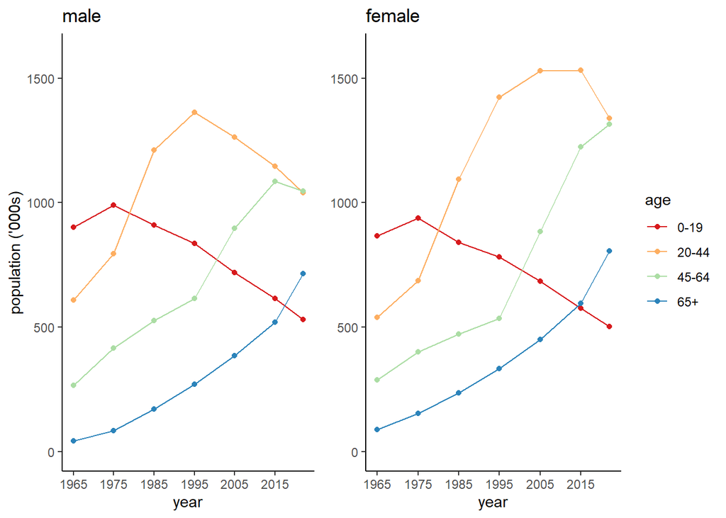

```r
if (!require("ggplot2")) install.packages("gglot2")
if (!require("gridExtra")) install.packages("gridExtra")
library(ggplot2)
library(gridExtra)
#Import the necessary packages and libraries
pmale<-ggplot(male,aes(x=year,y=`population ('000s)`,group=age))+
  geom_line(aes(color=age))+
  geom_point(aes(color=age))+
  scale_color_brewer(palette="Spectral")+
  theme_classic()+
  ylim(0,1600)+
  theme(legend.position="none")+
  scale_x_continuous(breaks = seq(1965, 2022, by = 10))+
  ggtitle("male")
pfemale<-ggplot(female,aes(x=year,y=`population ('000s)`,group=age))+
  geom_line(aes(color=age))+
  geom_point(aes(color=age))+
  scale_color_brewer(palette="Spectral")+
  theme_classic()+
  ylim(0,1600)+
  theme(legend.position="right",axis.title.y = element_blank())+
  scale_x_continuous(breaks = seq(1965, 2022, by = 10))+
  ggtitle("female")
grid.arrange(pmale,pfemale,ncol=2,widths=c(3,3.75))
```

## 3. Cancer registry data

It is clear that Hong Kong has an aging population, thus cancer incidence would also likely increase. To examine cancer incidence and mortality in Hong Kong you obtain data from the [Hong Kong Cancer Registry](https://www3.ha.org.hk/cancereg/), which is maintained by the Hospital Authority.

Cancer incidence data was summarised for the last three decades (1990-1999, 2000-2009 and 2010-2019).

Discussion points:

- Has incidence been increasing for most cancers? How about mortality?
- How has cancer risk and mortality rate changed in the past 3 decades?
- Has the incidence-to-mortality ratio been decreasing generally? Is it statistically significant?
- Which cancer type has the highest incidence in children (0-19) when compared with the elderly (65+). Is this statistically significantly different to incidence of children versus elderly cancers in general?

### Download cancer registry data

```r
HKCancer<- read.table("https://github.com/StatBiomed/BMDS-book/raw/main/notebooks/module5-epidemi/HK_cancer_incidence_mortality_1990-2020.txt",
                      sep = "\t", header = TRUE, stringsAsFactor=FALSE)
HKCancer
```

```
##         Type    Sex   Age      Year Biliary Bladder Brain Breast Cervix
## 1  incidence   male  0-19 1990-1999       0       6   212      0      0
## 2  incidence   male 20-44 1990-1999      36     165   368      6      0
## 3  incidence   male 45-64 1990-1999     322    1266   393     28      0
## 4  incidence   male   65+ 1990-1999     830    2920   318     35      0
## 5  incidence   male  0-19 2000-2009       0       2   206      0      0
## 6  incidence   male 20-44 2000-2009      31     103   267      9      0
## 7  incidence   male 45-64 2000-2009     297     900   372     52      0
## 8  incidence   male   65+ 2000-2009    1134    3103   299     96      0
## 9  incidence   male  0-19 2010-2019       0       2   155      0      0
## 10 incidence   male 20-44 2010-2019      28      18   276     14      0
## 11 incidence   male 45-64 2010-2019     530     648   511     72      0
## 12 incidence   male   65+ 2010-2019    1568    2399   380    107      0
## 13 incidence female  0-19 1990-1999       0       2   149      6      0
## 14 incidence female 20-44 1990-1999      52      62   283   4228   1263
```

[output cut: 279 more lines]

### 3a. Visualise changes in incidence and mortality

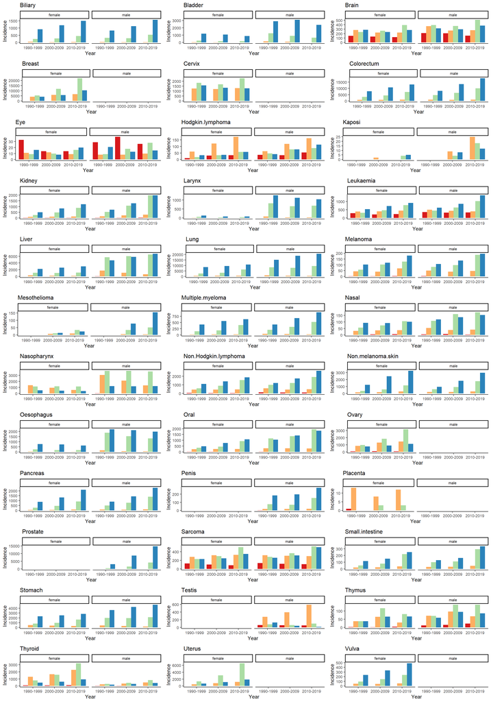

```r
# first plot incidence for each cancer type

#Import the necessary packages and libraries
if (!require("ggplot2")) install.packages("gglot2")
if (!require("gridExtra")) install.packages("gridExtra")
if (!require("ggpubr")) install.packages("ggpubr")
library(ggplot2)
library(gridExtra)
library(ggpubr)

HKCancer_inc <- HKCancer[HKCancer$Type=='incidence',]

p<-list()

for (i in 1:(ncol(HKCancer_inc)-4)){
  p[[i]]<-ggplot(HKCancer_inc,aes_string(fill=names(HKCancer_inc)[3],x=names(HKCancer_inc)[4],
                                         y=names(HKCancer_inc)[i+4],group=names(HKCancer_inc)[3]))+
       geom_bar(position="dodge",stat="identity")+
       facet_wrap(~Sex) +
       theme_classic()+
       scale_fill_brewer(palette="Spectral")+
       theme(legend.position="none")+
       theme(text = element_text(size = 10))+
       ggtitle(names(HKCancer_inc)[i+4])+
       ylab("Incidence")
}
do.call('grid.arrange',c(p,ncol=3,nrow=12))
```

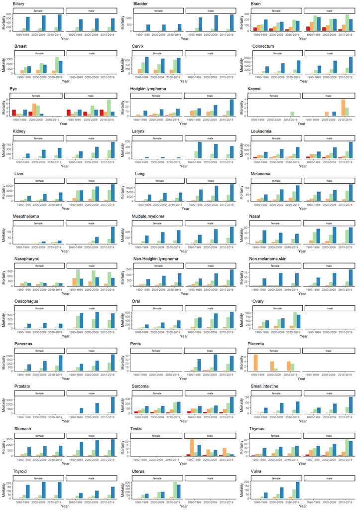

```r
# now plot mortality for each cancer type

#Import the necessary packages and libraries
if (!require("ggplot2")) install.packages("gglot2")
if (!require("gridExtra")) install.packages("gridExtra")
if (!require("ggpubr")) install.packages("ggpubr")
library(ggplot2)
library(gridExtra)
library(ggpubr)

HKCancer_mort <- HKCancer[HKCancer$Type=='mortality',]

p<-list()
#(ncol(HKCancer_inc)-4)
for (i in 1:(ncol(HKCancer_mort)-4)){
  p[[i]]<-ggplot(HKCancer_mort,aes_string(fill=names(HKCancer_mort)[3],x=names(HKCancer_mort)[4],
                                          y=names(HKCancer_mort)[i+4],group=names(HKCancer_mort)[3]))+
       geom_bar(position="dodge",stat="identity")+
       facet_wrap(~Sex) +
       theme_classic()+
       scale_fill_brewer(palette="Spectral")+
       theme(legend.position="none")+
       theme(text = element_text(size = 10))+
       ggtitle(names(HKCancer_mort)[i+4])+
       ylab("Mortality")
}
do.call('grid.arrange',c(p,ncol=3,nrow=12))
```

### 3b. Calculate cancer risk and mortality rate

To calculate disease risk we need to calculated the number of new cases over the number of persons at risk over a specific time period. We have the incidence for each decade and can estimate the number of persons at risk based on the population in 1995, 2005 and 2015.

```r
# cancer risk calculation

HKCancer_inc <- HKCancer[HKCancer$Type=='incidence',]
HKCancer_inc_risk <- HKCancer_inc[,1:5]

risk <- function(x,age,sex,year){
  if (is.integer(x)){
    pop_n <- HKPop %>% filter(Sex==sex & Age==age)
    if (year == "1990-1999"){ return (as.double(x)/as.double(pop_n$`1995`)) }
    else if (year == "2000-2009") {return (as.double(x)/as.double(pop_n$`2005`))}
    else { return (as.double(x)/as.double(pop_n$`2015`)) }
  }
  return (x)
}

for (i in 5:ncol(HKCancer_inc)){
  HKCancer_inc_risk[names(HKCancer_inc)[i]] <- mapply(risk,HKCancer_inc[,i],HKCancer_inc[,3],HKCancer_inc[,2],HKCancer_inc[,4])
}
```

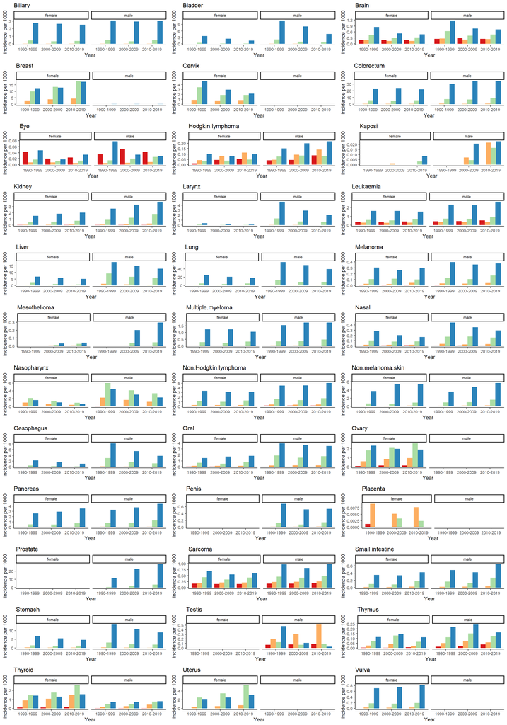

```r
#visualise cancer risk

p<-list()
for (i in 1:(ncol(HKCancer_inc_risk)-4)){
  p[[i]]<-ggplot(HKCancer_inc_risk,aes_string(fill=names(HKCancer_inc_risk)[3],x=names(HKCancer_inc_risk)[4],
                                              y=names(HKCancer_inc_risk)[i+4],group=names(HKCancer_inc_risk)[3]))+
       geom_bar(position="dodge",stat="identity")+
       facet_wrap(~Sex) +
       theme_classic()+
       scale_fill_brewer(palette="Spectral")+
       theme(legend.position="none")+
       theme(text = element_text(size = 10))+
       ggtitle(names(HKCancer_inc)[i+4])+
       ylab("incidence per 1000")
}
do.call('grid.arrange',c(p,ncol=3,nrow=12))
```

```r
# mortality rate calculation

HKCancer_mort <- HKCancer[HKCancer$Type=='mortality',]
HKCancer_mort_risk <- HKCancer_mort[,1:5]

risk <- function(x,age,sex,year){
  if (is.integer(x)){
    pop_n <- HKPop %>% filter(Sex==sex & Age==age)
    if (year == "1990-1999"){ return (as.double(x)/as.double(pop_n$`1995`)) }
    else if (year == "2000-2009") {return (as.double(x)/as.double(pop_n$`2005`))}
    else { return (as.double(x)/as.double(pop_n$`2015`)) }
  }
  return (x)
}

for (i in 5:ncol(HKCancer_mort)){
  HKCancer_mort_risk[names(HKCancer_mort)[i]] <- mapply(risk,HKCancer_mort[,i],HKCancer_mort[,3],HKCancer_mort[,2],HKCancer_mort[,4])
}
```

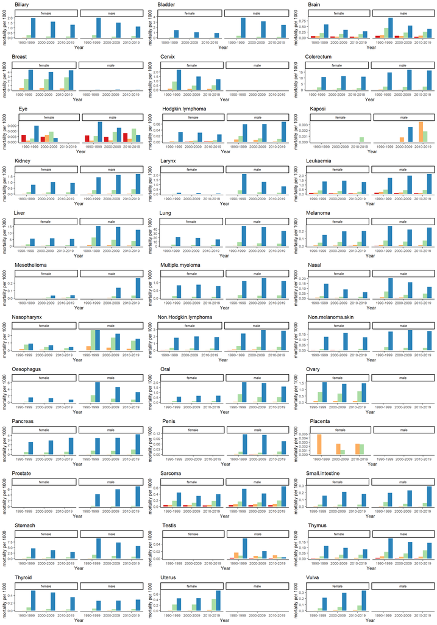

```r
#visualise mortality rate

p<-list()
for (i in 1:(ncol(HKCancer_mort_risk)-4)){
  p[[i]]<-ggplot(HKCancer_mort_risk,aes_string(fill=names(HKCancer_mort_risk)[3],x=names(HKCancer_mort_risk)[4],
                                               y=names(HKCancer_mort_risk)[i+4],group=names(HKCancer_mort_risk)[3]))+
       geom_bar(position="dodge",stat="identity")+
       facet_wrap(~Sex) +
       theme_classic()+
       scale_fill_brewer(palette="Spectral")+
       theme(legend.position="none")+
       theme(text = element_text(size = 10))+
       ggtitle(names(HKCancer_inc)[i+4])+
       ylab("mortality per 1000")
}
do.call('grid.arrange',c(p,ncol=3,nrow=12))
```

### 3c. Mortality-incidence ratio

Cancer research can be focused on improving cancer outcomes in a number of ways. For example cancer prevention research that seeks to reduce cancer incidence which would also ultimately reduce cancer mortality. Another area is cancer therapy which would not affect incidence but seeks to reduce mortality, or at least prolong survival. We don’t go into survival analysis in this tutorial, but a way to get an idea whether treatment is improving by looking at the mortality-incidence ratio.

```r
HKCancer_inc <- HKCancer[HKCancer$Type=='incidence',]
HKCancer_mort <- HKCancer[HKCancer$Type=='mortality',]
HKCancer_mort_inc <- HKCancer_mort[,1:5]

risk <- function(mort,inc){
  if (inc == 0){ return (0) }
  return (as.double(mort)/as.double(inc))
}

for (i in 5:ncol(HKCancer_mort)){
  HKCancer_mort_inc[names(HKCancer_mort)[i]] <- mapply(risk,HKCancer_mort[,i],HKCancer_inc[,i])
}
```

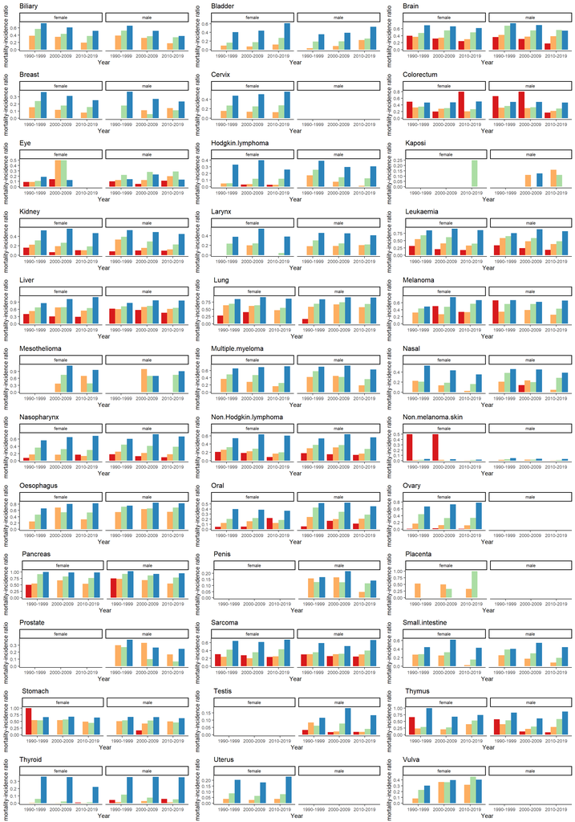

```r
#visualise mortality incidence ratio

p<-list()
for (i in 1:(ncol(HKCancer_mort_inc)-4)){
  p[[i]]<-ggplot(HKCancer_mort_inc,aes_string(fill=names(HKCancer_mort_inc)[3],x=names(HKCancer_mort_inc)[4],
                                              y=names(HKCancer_mort_inc)[i+4],group=names(HKCancer_mort_inc)[3]))+
       geom_bar(position="dodge",stat="identity")+
       facet_wrap(~Sex) +
       theme_classic()+
       scale_fill_brewer(palette="Spectral")+
       theme(legend.position="none")+
       theme(text = element_text(size = 10))+
       ggtitle(names(HKCancer_inc)[i+4])+
       ylab("mortality-incidence ratio")
}
do.call('grid.arrange',c(p,ncol=3,nrow=12))
```

### 3d. Paired t-test on mortality-incidence ratio change

In general, across the different cancer types is cancer treatment improving? We can use a paired t-test comparing the mortality-incidence ratio of cancers from the 1990-1999 period with the 2010-2019 period.

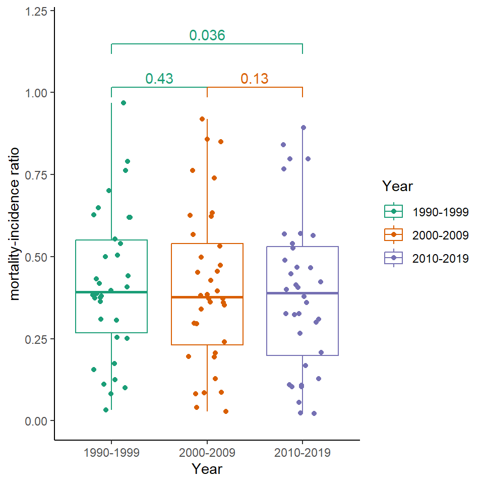

```r
#First sum up all incidence and mortality data for each cancer type across age and sex

HKCancer_inc_sum <- aggregate(HKCancer_inc[,-(1:4)],list(HKCancer_inc$Year),FUN=sum)
HKCancer_mort_sum <- aggregate(HKCancer_mort[,-(1:4)],list(HKCancer_mort$Year),FUN=sum)
HKCancer_mort_inc_year <- data.frame(Year=HKCancer_mort_sum[,1])

risk <- function(mort,inc){
  return (as.double(mort)/as.double(inc))
}

for (i in 2:ncol(HKCancer_mort_sum)){
  HKCancer_mort_inc_year[names(HKCancer_mort_sum)[i]] <- mapply(risk,HKCancer_mort_sum[,i],HKCancer_inc_sum[,i])
}

HKCancer_mort_inc_year_m <-data.frame(`1990-1999` = as.numeric(HKCancer_mort_inc_year[1,2:37]),
                                    `2000-2009` = as.numeric(HKCancer_mort_inc_year[2,2:37]),
                                    `2010-2019` = as.numeric(HKCancer_mort_inc_year[3,2:37]),
                                    check.names = FALSE)

HKCancer_mort_inc_year_m$Cancer <- names(HKCancer_mort_inc_year)[-1]

HKCancer_mort_inc_year_t<-as_tibble(HKCancer_mort_inc_year_m) %>% select(`Cancer`,`1990-1999`,`2000-2009`,`2010-2019`)%>% gather (key="Year",value="MIR",-Cancer)

plot<-ggplot(HKCancer_mort_inc_year_t,aes(x=Year,y=MIR, color=Year))+
       geom_boxplot(na.rm=T) +
       theme_classic()+
       scale_color_brewer(palette="Dark2")+
       geom_jitter(shape=16, position=position_jitter(0.2),na.rm=T)+
       ylab("mortality-incidence ratio")+
       ylim(0,1.2) + geom_signif(comparisons = list(c("1990-1999", "2010-2019")),
                                 map_signif_level=F, test= "t.test",test.args = list(paired = TRUE), na.rm = T, y_position = c(1.1, 1.3)) +
       geom_signif(comparisons = list(c("1990-1999", "2000-2009")), map_signif_level=F, test= "t.test",test.args = list(paired = TRUE), na.rm = T) +
       geom_signif(comparisons = list(c("2000-2009", "2010-2019")), map_signif_level=F, test= "t.test",test.args = list(paired = TRUE), na.rm = T)
plot
```

```r
p<-list()
p[[1]]<-t.test(HKCancer_mort_inc_year_m$`1990-1999`,HKCancer_mort_inc_year_m$`2000-2009`,paired=TRUE,alternative_m = "two.sided")
p[[2]]<-t.test(HKCancer_mort_inc_year_m$`1990-1999`,HKCancer_mort_inc_year_m$`2010-2019`,paired=TRUE,alternative_m = "two.sided")
p[[3]]<-t.test(HKCancer_mort_inc_year_m$`2000-2009`,HKCancer_mort_inc_year_m$`2010-2019`,paired=TRUE,alternative_m = "two.sided")
p
```

```
## [[1]]
##
##  Paired t-test
##
## data:  HKCancer_mort_inc_year_m$`1990-1999` and HKCancer_mort_inc_year_m$`2000-2009`
## t = 0.79695, df = 33, p-value = 0.4312
## alternative hypothesis: true mean difference is not equal to 0
## 95 percent confidence interval:
##  -0.01415536  0.03238636
## sample estimates:
## mean difference
##     0.009115498
##
##
## [[2]]
##
##  Paired t-test
##
## data:  HKCancer_mort_inc_year_m$`1990-1999` and HKCancer_mort_inc_year_m$`2010-2019`
## t = 2.1861, df = 33, p-value = 0.036
## alternative hypothesis: true mean difference is not equal to 0
## 95 percent confidence interval:
##  0.002055217 0.057209924
## sample estimates:
## mean difference
##      0.02963257
##
##
## [[3]]
##
##  Paired t-test
##
## data:  HKCancer_mort_inc_year_m$`2000-2009` and HKCancer_mort_inc_year_m$`2010-2019`
## t = 1.5413, df = 35, p-value = 0.1322
## alternative hypothesis: true mean difference is not equal to 0
## 95 percent confidence interval:
##  -0.005438019  0.039734021
## sample estimates:
## mean difference
##        0.017148
```

### 3e. Childhood versus elderly cancers

Although it is clear that the incidence of cancer is typically higher in the elderly, some cancers affect children as well. What cancer types disproportionate affect children? For each cancer type, compare the proportion of 0-19 versus 65+ incidence against the 0-19 versus 65+ incidence for all other cancer types.

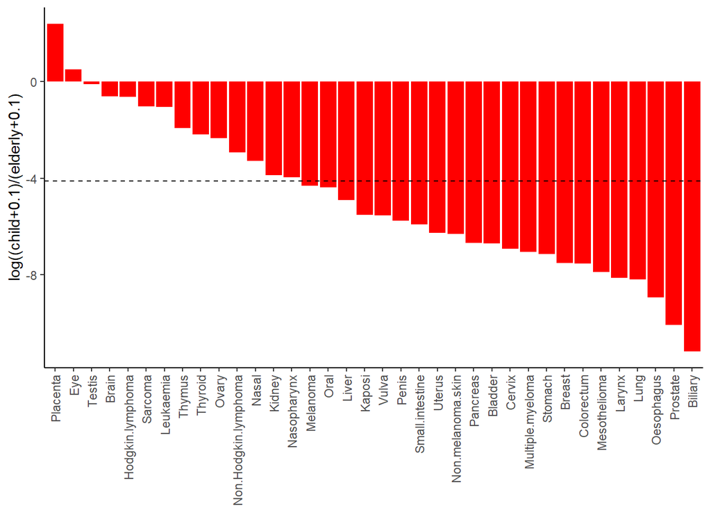

```r
# Examine the proportion of childhood

HKCancer_inc <- HKCancer[HKCancer$Type=='incidence',]
HKCancer_inc_age_sum <- aggregate(HKCancer_inc[,-(1:4)],list(HKCancer_inc$Age),FUN=sum)
HKCancer_inc_age_sum$Total<- rowSums(HKCancer_inc_age_sum[,-1])
HKCancer_inc_age_sum_csq <-  data.frame(cancer=names(HKCancer_inc_age_sum[,2:ncol(HKCancer_inc_age_sum)]))

pval <- list()
ratio <- list()
for (i in 2:(ncol(HKCancer_inc_age_sum))){
  val = Map('-',HKCancer_inc_age_sum$Total,HKCancer_inc_age_sum[,i])
  dat <- data.frame(cancer=HKCancer_inc_age_sum[c(1,4),i], other =c(val[[1]],val[[2]]))
  pval <- append(pval,fisher.test(dat)$p.val)
  ratio<- append(ratio,log(as.double(dat[1,1]+0.1)/as.double(dat[2,1]+0.1)))
}
HKCancer_inc_age_sum_csq$pval <- pval
HKCancer_inc_age_sum_csq$ratio <- ratio

plot_child<-ggplot(HKCancer_inc_age_sum_csq[-37,],aes(x=reorder(cancer,-as.numeric(ratio)),y=as.numeric(ratio)),fill=cancer)+
       geom_bar(stat="identity",fill="red")+
       geom_hline(yintercept=-4.12132318942113, linetype="dashed",
                color = "black", linewidth=0.5)+
       theme_classic()+
       scale_fill_brewer(palette="Spectral")+
       theme(legend.position="none")+
       #theme(text = element_text(size = 10))+
       theme(axis.title.x=element_blank())+
       theme(axis.text.x = element_text(angle = 90, vjust = 0.5, hjust=1)) +
       ylab("log((child+0.1)/(elderly+0.1)")
plot_child
```

```r
HKCancer_inc_age_sum_csq
```

```
##                  cancer          pval       ratio
## 1               Biliary  1.21618e-216   -11.17481
## 2               Bladder 9.601084e-314   -6.711128
## 3                 Brain             0   -0.615666
## 4                Breast             0   -7.519824
## 5                Cervix 1.635299e-126   -6.925188
## 6            Colorectum             0   -7.531208
## 7                   Eye 2.085337e-112   0.5039276
## 8      Hodgkin.lymphoma  3.658856e-81  -0.6227962
## 9                Kaposi       0.41662   -5.525453
## 10               Kidney  1.560619e-71   -3.882371
## 11               Larynx 1.963055e-113   -8.129416
## 12            Leukaemia             0   -1.043172
## 13                Liver             0   -4.909033
## 14                 Lung             0   -8.191896
```

[output cut: 23 more lines]

## 4. Exising cancer funding data